# Advanced Empirical Finance: Topics and Data Science

Machine learning foundations

Stefan Voigt

University of Copenhagen and Danish Finance Institute (DFI)

Spring 2027

## Today

- The factor zoo: 158 anomalies, one portfolio
- Overfitting
- The bias-variance trade-off: ridge and lasso

## From 27 stocks to 158 anomalies

- **Lectures 2 to 5:** with 27 Dow Jones stocks, the plug-in portfolio already failed out of sample, and shrinkage helped
- **Lectures 7 to 9:** a portfolio sort turns a characteristic into a long-short portfolio. Researchers have published hundreds of them: the factor zoo
- **Today:** which combination of the zoo should an investor hold? The mean-variance efficient portfolio of the anomalies is also the SDF that prices them (lecture 6)

The machine learning lectures use one dataset, one sample split and one scoreboard: every method adds a row

## The factor zoo

- R
- Python

```r
osap_url <- paste0(
  "https://huggingface.co/datasets/OpenSourceAP/CrossSection/resolve/",
  "Data-Release-2026.10/Portfolios/Full%20Sets%20OP/PredictorLSretWide.parquet"
)
osap_file <- "data/osap_long_short_returns.parquet"
if (!file.exists(osap_file)) download.file(osap_url, osap_file, mode = "wb")

# Anomalies with a return in every month; the returns are in percent
anomalies <- read_parquet(osap_file) |>
  mutate(date = floor_date(as.Date(date), "month")) |>
  filter(between(date, sample_start, sample_end)) |>
  select(date, where(\(x) !anyNA(x)))
returns <- as.matrix(select(anomalies, -date)) / 100
estimation <- anomalies$date < test_start
```

```python
osap_url = (
    "https://huggingface.co/datasets/OpenSourceAP/CrossSection/resolve/"
    "Data-Release-2026.10/Portfolios/Full%20Sets%20OP/PredictorLSretWide.parquet"
)
pl.read_parquet(osap_url).write_parquet("data/osap_long_short_returns.parquet")

anomalies = (pl.read_parquet("data/osap_long_short_returns.parquet")
    .with_columns(pl.col("date").dt.truncate("1mo"))
    .filter(pl.col("date").is_between(date(1973, 1, 1), date(2023, 12, 31)))
)
# Anomalies with a return in every month; the returns are in percent
complete = [c for c in anomalies.columns if c != "date" and anomalies[c].null_count() == 0]
returns = anomalies.select(complete).to_numpy() / 100
estimation = (anomalies["date"] < date(2000, 1, 1)).to_numpy()
```

158 long-short portfolios from Open Source Asset Pricing (Chen & Zimmermann), the same data as exercise 5: estimation sample 1973–1999 (324 months), test sample 2000–2023 (288 months)

## Sharpe ratios in both samples

- R
- Python

```r
sharpe_ratio <- function(x) mean(x) / sd(x) * sqrt(months_per_year)

portfolio_sharpe <- function(weights) {
  c(
    estimation = sharpe_ratio(returns[estimation, ] %*% weights),
    test = sharpe_ratio(returns[!estimation, ] %*% weights)
  )
}

equal_weights <- rep(1 / ncol(returns), ncol(returns))
```

```python
def sharpe_ratio(x):
    return np.mean(x) / np.std(x, ddof=1) * np.sqrt(12)


def portfolio_sharpe(weights):
    return {"estimation": sharpe_ratio(returns[estimation] @ weights),
            "test": sharpe_ratio(returns[~estimation] @ weights)}


equal_weights = np.full(returns.shape[1], 1 / returns.shape[1])
```

- **Market:** Sharpe ratio 0.47 until 1999, 0.42 since 2000
- **1/N over all anomalies:** 2.79 until 1999, 1.43 since 2000. Diversifying across the zoo beats the market by far, but the anomalies lost half of their Sharpe ratio after 1999

## The plug-in portfolio of the zoo

- The mean-variance efficient weights are proportional to $\hat\Sigma^{-1}\hat\mu$. Britten-Jones (1999): the same weights come from a regression of a vector of ones on the returns, without an intercept
- R
- Python

```r
x_estimation <- returns[estimation, ]
plug_in_weights <- solve(crossprod(x_estimation), colSums(x_estimation))
```

```python
x_estimation = returns[estimation]
plug_in_weights = np.linalg.solve(x_estimation.T @ x_estimation, x_estimation.sum(axis=0))
```

- 158 weights from 324 months. In the estimation sample, this portfolio has a Sharpe ratio of **15.7**

## Your guess: the Sharpe ratio since 2000

In the estimation sample, the plug-in portfolio of the zoo has a Sharpe ratio of 15.7. What is its Sharpe ratio from 2000 to 2023, with the weights estimated until 1999?

## Overfitting

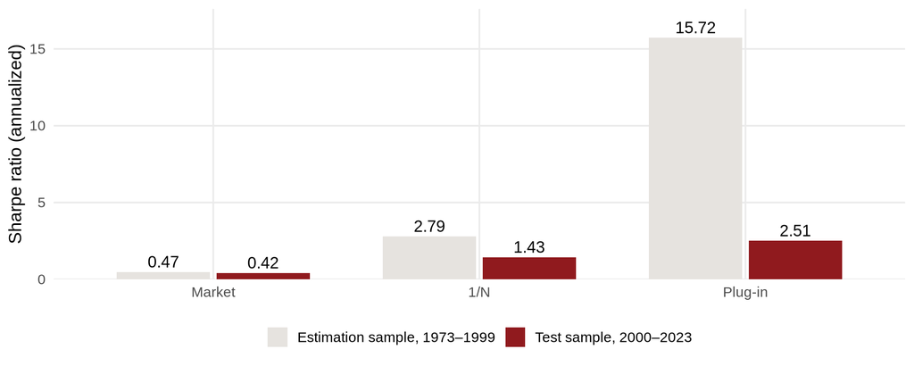

- In the test sample, the plug-in portfolio keeps 16% of its Sharpe ratio: the weights fit the noise of 324 months as well as the signal
- Still 2.51 against 1.43 for 1/N: there is something to learn from the data, if we learn less of the noise

# The bias-variance trade-off

## Whiteboard: the bias-variance trade-off

A new observation $y = f(x) + \varepsilon$ and an estimate $\hat f(x)$ from a sample. Split the expected squared error $E\big[(y - \hat f(x))^2\big]$

$$E\big[(y - \hat f(x))^2\big] = \underbrace{\big(f(x) - E[\hat f(x)]\big)^2}_{\text{bias}^2} + \underbrace{\text{Var}\big(\hat f(x)\big)}_{\text{variance}} + \underbrace{\sigma_\varepsilon^2}_{\text{noise}}$$

- OLS is unbiased, but with 158 regressors and 324 months its variance is huge
- A little bias for much less variance: a **penalty** on large coefficients. The same idea as the shrinkage of covariance matrices in lecture 4

## Whiteboard: ridge regression

$$\hat b_\lambda = \arg\min_b \ \frac{1}{2T}(y - Xb)'(y - Xb) + \frac{\lambda}{2}\, b'b$$

$$\hat b_\lambda = (X'X + T\lambda I)^{-1}X'y \qquad X\hat b_\lambda = \sum_j u_j\, \frac{d_j^2}{d_j^2 + T\lambda}\, u_j'y \quad \text{with } X = UDV'$$

- Ridge shrinks most where the data vary least, $d_j$ small: the combinations of anomalies that look best in the sample, because their variance is underestimated
- $\lambda = 0$: the plug-in portfolio. $\lambda \to \infty$: weights proportional to $X'y$, the average returns, as if all anomalies were uncorrelated

## Ridge on the zoo

- R
- Python

```r
ridge_weights <- function(x, lambda) {
  solve(crossprod(x) + nrow(x) * lambda * diag(ncol(x)), colSums(x))
}

ridge_path <- map(ridge_lambdas, \(lambda) {
  weights <- ridge_weights(x_estimation, lambda)
  tibble(lambda = lambda, weights = list(weights), !!!portfolio_sharpe(weights))
}) |>
  bind_rows()
```

```python
def ridge_weights(x, lam):
    return np.linalg.solve(x.T @ x + len(x) * lam * np.eye(x.shape[1]), x.sum(axis=0))


ridge_lambdas = 10 ** np.arange(-7, -0.99, 0.25)
ridge_path = pl.DataFrame([
    {"lambda": lam, **portfolio_sharpe(ridge_weights(x_estimation, lam))}
    for lam in ridge_lambdas
])
```

$y$ is a vector of ones, so $X'y$ is the sum of each anomaly’s returns, `colSums(x)`; the penalty is scaled as in `glmnet()`

## The penalty in action

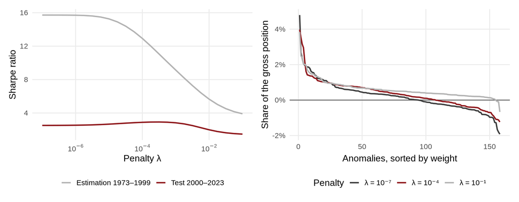

- The larger $\lambda$, the lower the Sharpe ratio in the estimation sample. In the test sample it first rises, from 2.51 to 2.92, then falls: too little and too much shrinkage both cost
- Small penalties bet heavily long and short on a few combinations; large ones spread the weights

## Whiteboard: the lasso

$$\hat b_\lambda = \arg\min_b \ \frac{1}{2T}(y - Xb)'(y - Xb) + \lambda \sum_i |b_i|$$

- No closed form. With orthonormal regressors, each coefficient is **soft-thresholded**: $\hat b_i = \text{sign}(\hat b_i^{\text{OLS}})\max\big(|\hat b_i^{\text{OLS}}| - \lambda, 0\big)$
- The corners of the $L_1$ ball set coefficients to exactly zero: the lasso **selects** anomalies
- **Elastic net:** a mix of both penalties, for groups of similar anomalies

## The lasso in code

- R
- Python

```r
# A tight convergence threshold, so that R and Python agree on the weights
lasso_weights <- function(x, lambda) {
  fit <- glmnet(
    x, rep(1, nrow(x)), lambda = lambda, intercept = FALSE, standardize = FALSE,
    control = list(thresh = 1e-12)
  )
  as.vector(coef(fit))[-1]
}

lasso_path <- map(lasso_lambdas, \(lambda) {
  weights <- lasso_weights(x_estimation, lambda)
  tibble(lambda = lambda, anomalies = sum(weights != 0), !!!portfolio_sharpe(weights))
}) |>
  bind_rows()
```

```python
def lasso_weights(x, lam):
    fit = Lasso(alpha=lam, fit_intercept=False, max_iter=100_000).fit(x, np.ones(len(x)))
    return fit.coef_


lasso_lambdas = 10 ** np.arange(-6, -2.49, 0.25)
lasso_path = pl.DataFrame([
    {"lambda": lam, "anomalies": int(np.sum(w != 0)), **portfolio_sharpe(w)}
    for lam in lasso_lambdas
    for w in [lasso_weights(x_estimation, lam)]
])
```

`glmnet()` and `Lasso()` minimize the same objective: $\frac{1}{2T}$ times the squared errors plus $\lambda$ times the sum of absolute weights

## The lasso on the zoo

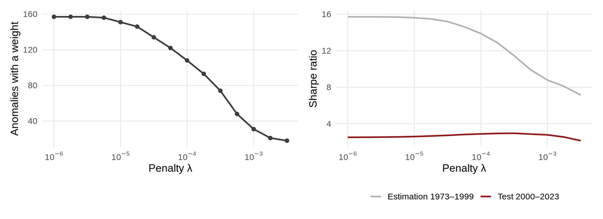

- The larger $\lambda$, the fewer anomalies get a weight, from all 158 down to 18
- In hindsight, 74 anomalies do best in the test sample (Sharpe ratio 2.96), better than all of them. But picking $\lambda$ by the test sample would be overfitting again

## Scoreboard

| Portfolio | Anomalies | Sharpe ratio 1973–1999 | Sharpe ratio 2000–2023 |
| --- | --- | --- | --- |
| Market | – | 0.47 | 0.42 |
| 1/N over all anomalies | 158 | 2.79 | 1.43 |
| Plug-in mean-variance | 158 | 15.72 | 2.51 |

- Ridge and the lasso beat the plug-in portfolio in the test sample for a wide range of penalties, but which $\lambda$ do we choose without looking at the test sample?
- **Lecture 11:** choosing the penalty by cross-validation, and an economic reason for it, the ridge SDF of Kozak, Nagel & Santosh (2020)